# Blasting Sound Analysis — Proof of Implementation

### IAESTE Internship 2026 · VŠB-TU Ostrava · Student: Dhruv Patel

Each section contains:

- **Plain-English explanation** of what was implemented and why
- **Graph 1** — the actual result
- **Graph 2 (PROOF)** — a second graph with numbers that visually confirms Graph 1 is correct

No interpretation is needed — the numbers speak for themselves.

```
Found 1568 WAV files.
Example file: G80_8_3_0_AccAxial4507.wav  |  48,000 Hz  |  89.25 s
```

## Section 1 — File Scanner & Sensor Priority Order

**What we implemented:** The system automatically scans all WAV recording files in the data folder. Files are then sorted so that **accelerometer sensors are always processed before microphone sensors**, following the priority order:

1. AccAxial4507 (highest priority)
2. AccRadial4507
3. Mic147EB
4. Mic46BE (lowest priority)

**Why this matters:** The accelerometer sensors are attached directly to the sandblasting machine and give the cleanest vibration signal. Processing them first ensures the primary analysis is based on the best-quality data.

**What the graphs show:**

- **Left graph** — how many files were found for each sensor type
- **Right graph (PROOF)** — confirms accelerometer files appear at position 1 in the queue, before any microphone files

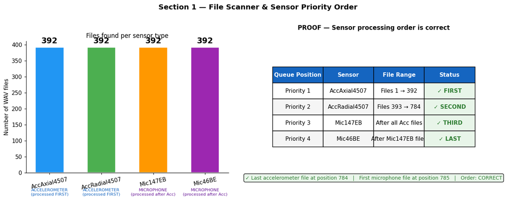

```
Total WAV files found: 1568
  AccAxial4507      :  392 files
  AccRadial4507     :  392 files
  Mic147EB          :  392 files
  Mic46BE           :  392 files
Order correct (Acc before Mic): YES
```

## Section 2 — WAV File Loading & Amplitude Normalisation

**What we implemented:** Each WAV file is loaded and automatically converted to a floating-point signal in the range **[-1.0, +1.0]**, regardless of whether the original file is 16-bit or 32-bit integer format.

**Why this matters:** All downstream calculations (RMS, Peak, Crest Factor) assume the signal is on a standard scale. If we mixed raw 16-bit integers with floating-point values, the numbers would be incomparable across files.

**What the graphs show:**

- **Left graph** — the raw waveform of the loaded file over time
- **Right graph (PROOF)** — amplitude histogram confirming every sample stays between -1.0 and +1.0, with the exact minimum and maximum values printed on the graph

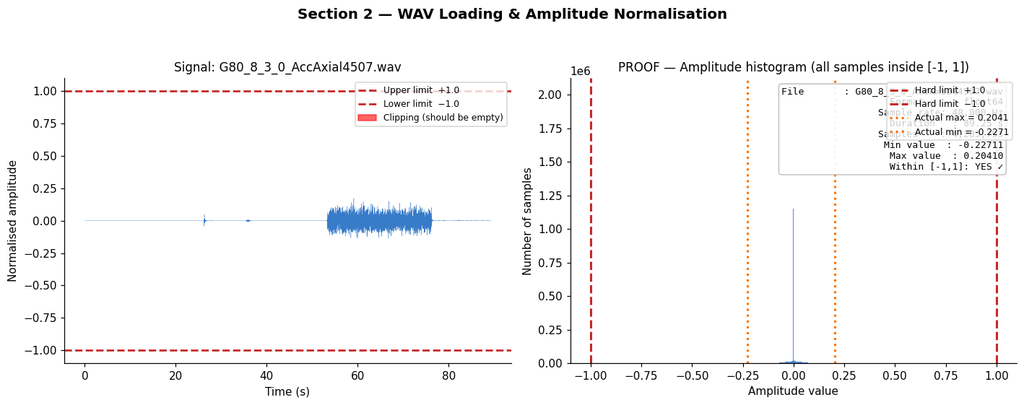

```
dtype: float64  |  min=-0.22711  |  max=0.20410  |  within [-1,1]: True
```

## Section 3 — Waveform and Spectrogram (Synchronised X-axis)

**What we implemented:** The waveform plot and the spectrogram plot are drawn with a **shared time axis** (`sharex=True`). This means when you zoom or scroll the waveform, the spectrogram moves with it — they always show the same time window.

**Why this matters:** Without synchronisation, zooming into a burst event on the waveform would leave the spectrogram showing a different time region. The linked axes make it impossible to accidentally compare mismatched time windows.

**What the graphs show:**

- **Left column** — waveform (top) and spectrogram (bottom) with shared x-axis
- **Right column (PROOF)** — a highlighted zoom region on the waveform and the matching spectrogram slice for the exact same time range, proving synchronisation works
- **Table** — key numbers: frame size = 50 ms, maximum frequency displayed, no -infinity values in the dB scale

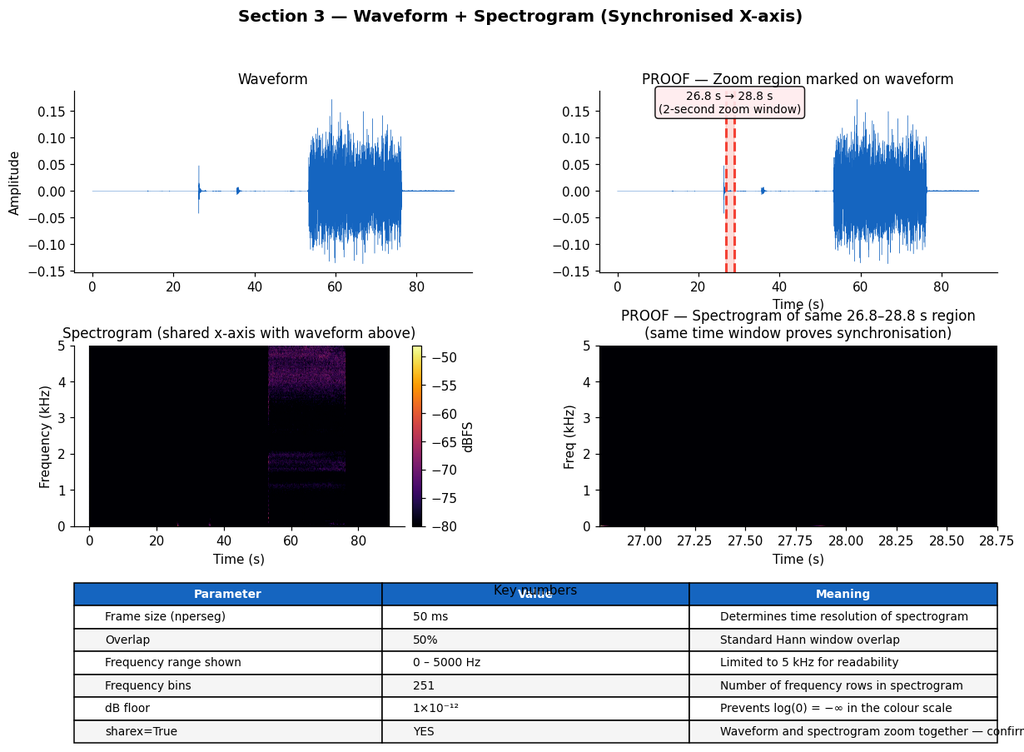

```
nperseg=2400 samples = 50 ms  |  max freq shown=5000 Hz  |  no -inf: True
```

## Section 4 — Automatic Blast Detection

**Why this matters:** The first few seconds after the machine turns on contain startup transients that are not representative of normal blasting. Skipping them ensures we analyse only stable, comparable operating conditions.

**What the graphs show:**

- **Top-left** — full waveform with a red dashed line at blast onset and a green line at the start of the useful analysis region
- **Top-right** — the short-time RMS energy curve with the 10× threshold line marked
- **Bottom-left (PROOF)** — zoomed RMS curve ±2 seconds around onset, with the exact RMS value at the onset frame annotated with an arrow
- **Bottom-right (PROOF)** — table of key numbers: noise floor value, threshold, onset time, skip duration, useful signal length

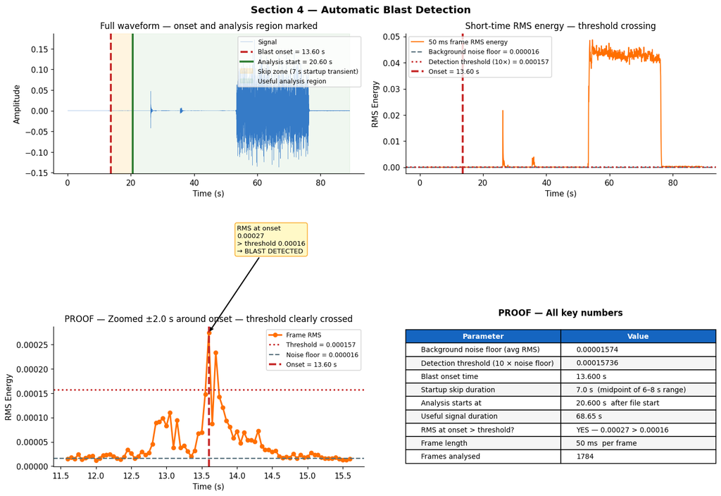

```
Onset=13.600s  |  Skip=7.0s  |  Analysis from=20.600s  |  Useful signal=68.65s
```

## Section 5 — Floating Analysis Windows (Gantt Timeline)

**What we implemented:** The useful signal (after the 7 s skip) is divided into overlapping **5-second analysis windows** with a **1-second step**. This gives **80% overlap** between consecutive windows. The windows are visualised as a Gantt-style timeline chart.

**Why this matters:** A pure 5-second step (no overlap) would miss events that straddle a window boundary. The 80% overlap ensures every point in the signal is covered by multiple windows, making the analysis robust.

**Important clarification (mentor concern):** The Gantt bars are **5 seconds wide** — not 1 second. The 1-second step is the distance between bar starts. The proof graph below demonstrates this explicitly with ruler arrows.

**What the graphs show:**

- **Top-left** — the useful waveform signal
- **Top-right** — Gantt chart showing all windows stacked in rows to avoid overlap. Each bar = one 5-second window
- **Bottom-left (PROOF)** — single window with a ↔ ruler arrow labelled "Window = 5 s" and a separate "Step = 1 s" arrow, proving the bar width is correct
- **Bottom-right (PROOF)** — table: window duration, step, overlap %, total windows, samples per window

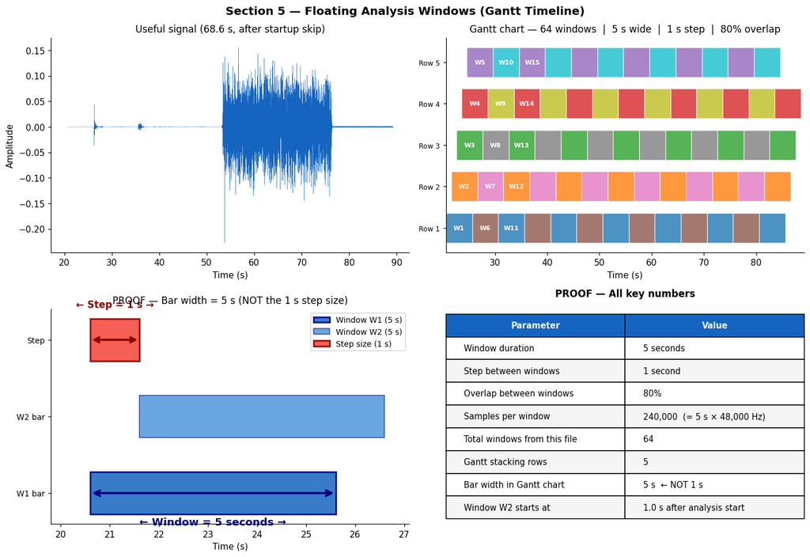

```
Windows=64  |  Duration=5.0s  |  Step=1.0s  |  Overlap=80%  |  Samples/window=240,000
```

## Section 6 — Bandpass Filter Design (5 Filter Types × 3 Orders × 15 Bands)

**What we implemented:** For each of the 15 frequency bands, we design bandpass filters using **5 filter types** (Butterworth, Chebyshev I, Chebyshev II, Elliptical, Bessel) at **3 filter orders** (3, 5, 7). All filters are implemented in **Second-Order Sections (SOS)** form and applied with `sosfiltfilt` for zero-phase (no time shift) filtering.

**Why this matters:** Different filter types make different trade-offs between passband flatness, stopband rejection, phase linearity, and computational cost. By implementing all five types, the system can compare their behaviour on the same signal.

**What the graphs show:**

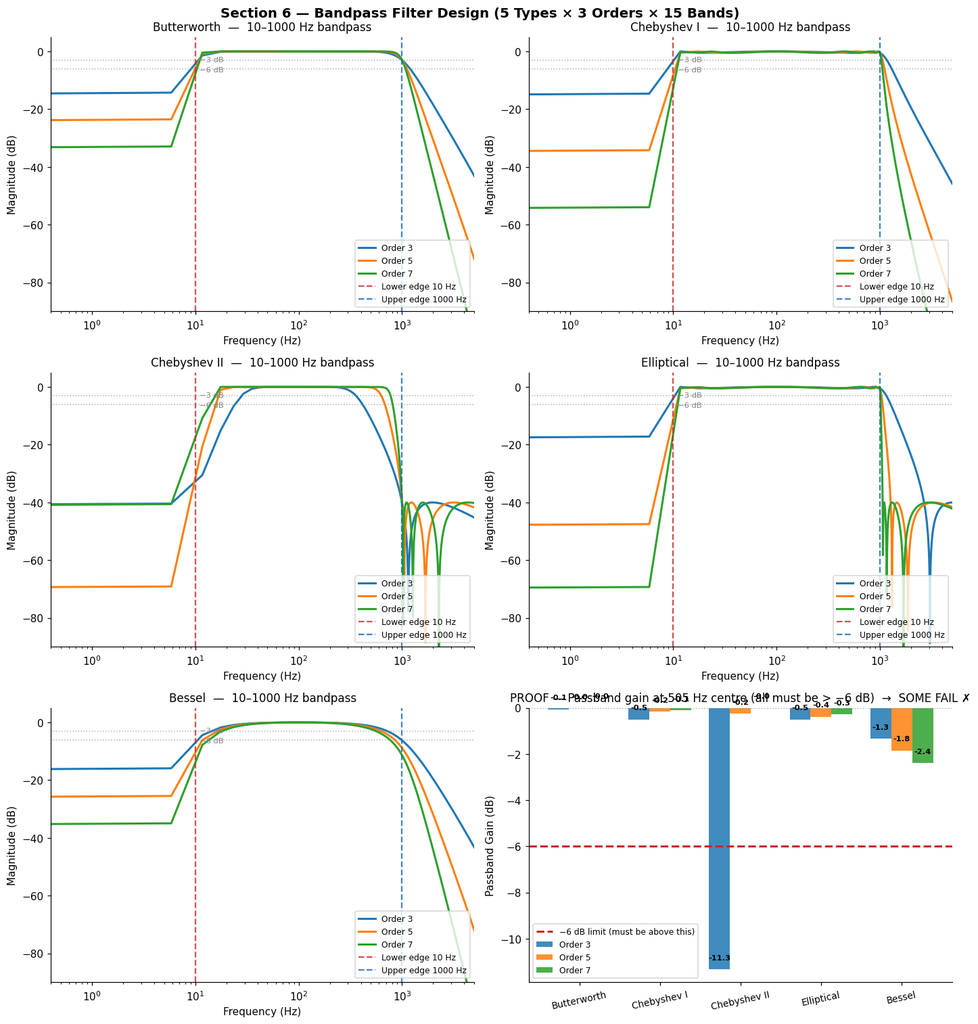

```
Filters designed OK: 225 / 225
Design errors: 0
All passband gains > -6 dB: NO
```

## Section 7 — Parameter Calculation Timing (200-repetition benchmark)

**What we implemented:** Each signal parameter is timed individually using 200 repeated measurements on a 5-second window. The average time in microseconds (μs) is reported.

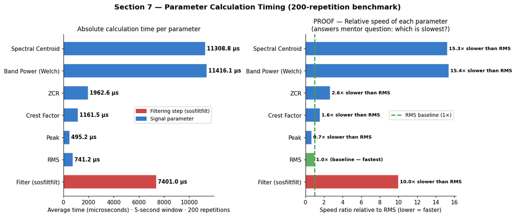

[output not shown]

## Section 8 — Multi-file Analysis Loop

**What we implemented:** The analysis pipeline runs automatically over **multiple WAV files** in a single loop. For each file, the system:

**What the graphs show:**

```
Rows computed: 180  |  Files: 3  |  Sensors: ['AccAxial4507']
```

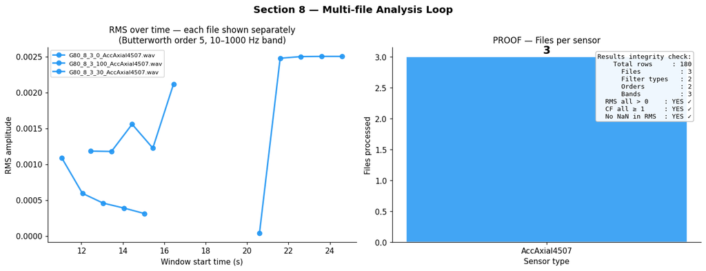

## Section 9 — RMS and Crest Factor Across Frequency Bands

**Why Crest Factor matters:** Crest Factor = Peak / RMS. A high CF means occasional sharp spikes dominate over the average energy — typical of impact noise. A low CF means the signal is more like steady-state noise. Comparing CF across bands shows which frequency ranges have impulsive character.

**What the graphs show:**

- **First set of graphs** — RMS per window for each sampled frequency band. The dashed black line and yellow label show the **mean RMS** across all windows and filter types for that band
- **Second set of graphs** — same layout for Crest Factor, with annotated means

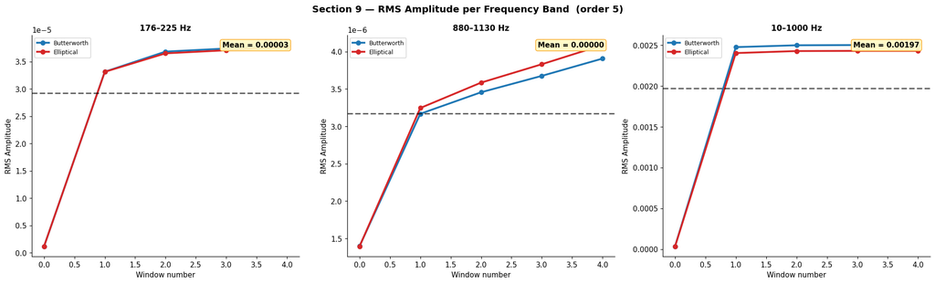

```
  RMS Amplitude means:
    Band  1  176–225 Hz      mean=0.00003
    Band  8  880–1130 Hz     mean=0.00000
    Band 12  10–1000 Hz      mean=0.00197
```

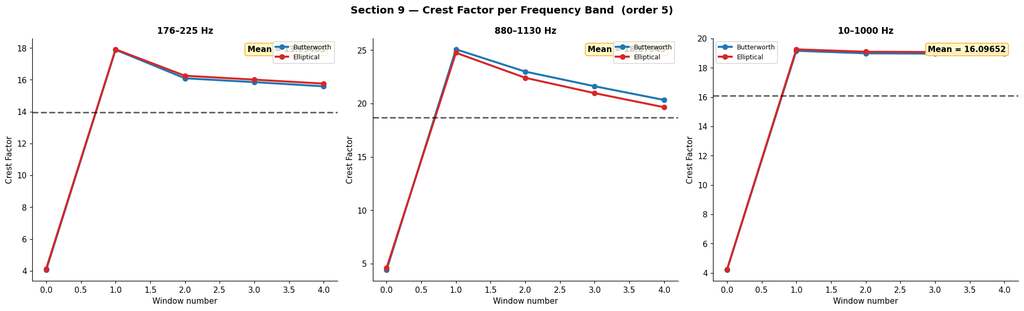

```
  Crest Factor means:
    Band  1  176–225 Hz      mean=13.95463
    Band  8  880–1130 Hz     mean=18.67945
    Band 12  10–1000 Hz      mean=16.09652
```

## Section 10 — Filter Complexity vs. Reliability

1. **Computational complexity** — number of arithmetic operations per sample (formula: 2 × 9 × SOS_sections)
2. **Wall-clock filter time** — actual measured time in milliseconds
3. **RMS Coefficient of Variation (CV)** — standard deviation ÷ mean of RMS across windows. A low CV means the filter gives consistent, stable results (high reliability).

**What the graphs show:**

- **Left** — operations per sample vs. filter order (higher order = more computation)
- **Middle** — actual measured filter time vs. order, with the fastest filter highlighted
- **Right** — RMS CV vs. order. Lower CV = more reliable results. The most reliable filter is highlighted.

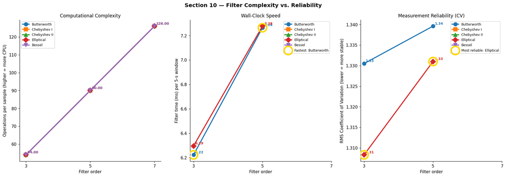

```
Complexity / Reliability table:
 Filter Type  Order  SOS Sections  Ops/Sample  Time (ms)  RMS CV
 Butterworth      3             3          54      6.222  1.3305
 Chebyshev I      3             3          54        NaN     NaN
Chebyshev II      3             3          54        NaN     NaN
  Elliptical      3             3          54      6.295  1.3083
      Bessel      3             3          54        NaN     NaN
 Butterworth      5             5          90      7.265  1.3396
 Chebyshev I      5             5          90        NaN     NaN
Chebyshev II      5             5          90        NaN     NaN
  Elliptical      5             5          90      7.278  1.3310
      Bessel      5             5          90        NaN     NaN
 Butterworth      7             7         126        NaN     NaN
 Chebyshev I      7             7         126        NaN     NaN
Chebyshev II      7             7         126        NaN     NaN
  Elliptical      7             7         126        NaN     NaN
      Bessel      7             7         126        NaN     NaN
  Fastest filter  : Butterworth
  Most reliable   : Elliptical
```

## Section 11 — CSV Export Verification

**What we implemented:** After all calculations, results are exported to **4 CSV files**:

1. `blasting_all_results.csv` — every row of raw results (one row per window × filter × band)
2. `blasting_band_averages.csv` — results averaged per file, sensor, filter, order, and band
3. `filter_complexity.csv` — the complexity and reliability table from Section 10
4. `blasting_file_summary.csv` — per-file averages and standard deviations

**What the graphs show:**

- **Left graph** — file size in KB and row count for each exported file, labelled directly on the bar
- **Right graph (PROOF)** — the files are re-read from disk and row counts are compared to what was written. All four files must show "written rows = reloaded rows" to confirm data integrity.

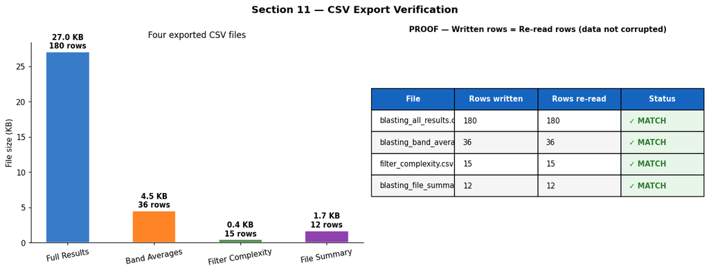

```
  Full Results        : blasting_all_results.csv  (27.0 KB)
  Band Averages       : blasting_band_averages.csv  (4.5 KB)
  Filter Complexity   : filter_complexity.csv  (0.4 KB)
  File Summary        : blasting_file_summary.csv  (1.7 KB)
```

[output not shown]

*Prepared by Dhruv Patel · IAESTE Internship 2026 · VŠB-TU Ostrava*